# Homework 2

梁凯毅 3170104603

The data set calif_penn_2011.csv contains information about the housing stock of California and Pennsylvania, as of 2011. Information as aggregated into “Census tracts”, geographic regions of a few thousand people which are supposed to be fairly homogeneous economically and socially.

1. *Loading and cleaning*
1. Load the data into a dataframe called `ca_pa`.

**解**：

```r
ca_pa<-read_csv("../data/calif_penn_2011.csv")
```

2. How many rows and columns does the dataframe have?

**解**：

```r
dim(ca_pa)
```

```
## [1] 11275    34
```

3. Run this command, and explain, in words, what this does:

```r
colSums(apply(ca_pa,c(1,2),is.na))
```

```
##                          X1                     GEO.id2
##                           0                           0
##                     STATEFP                    COUNTYFP
##                           0                           0
##                     TRACTCE                  POPULATION
##                           0                           0
##                    LATITUDE                   LONGITUDE
##                           0                           0
##           GEO.display.label          Median_house_value
##                           0                         599
##                 Total_units                Vacant_units
##                           0                           0
##                Median_rooms  Mean_household_size_owners
##                         157                         215
## Mean_household_size_renters         Built_2005_or_later
##                         152                          98
##          Built_2000_to_2004                 Built_1990s
##                          98                          98
##                 Built_1980s                 Built_1970s
##                          98                          98
##                 Built_1960s                 Built_1950s
##                          98                          98
##                 Built_1940s       Built_1939_or_earlier
##                          98                          98
##                  Bedrooms_0                  Bedrooms_1
##                          98                          98
##                  Bedrooms_2                  Bedrooms_3
##                          98                          98
##                  Bedrooms_4          Bedrooms_5_or_more
##                          98                          98
##                      Owners                     Renters
##                         100                         100
##     Median_household_income       Mean_household_income
##                         115                         126
```

**解**： apply语句将ca_pa数据按列分割传入is.na函数中，求出没列的缺省值情况，用TRUE和FALSE分别表示缺省与否。colSums函数对一个数据的每列求和，如果是bool值，则求和就是求其TRUE的个数。语句整体的效果是求出每一列中有多少缺省值。

4. The function `na.omit()` takes a dataframe and returns a new dataframe, omitting any row containing an NA value. Use it to purge the data set of rows with incomplete data.

**解**：

```r
ca_pa1<-na.omit(ca_pa)
```

5. How many rows did this eliminate?

**解**：

```r
dim(ca_pa)[[1]]-dim(ca_pa1)[[1]]
```

```
## [1] 670
```

6. Are your answers in (c) and (e) compatible? Explain.

**解**： 不能并行，因为(c)中是对每列计算有多少缺省值，而不能判断出那些缺省值在同一行中，所以并不能判断一共需要删去多少行。

2. *This Very New House*
   1. The variable `Built_2005_or_later` indicates the percentage of houses in each Census tract built since 2005. Plot median house prices against this variable.

**解**：

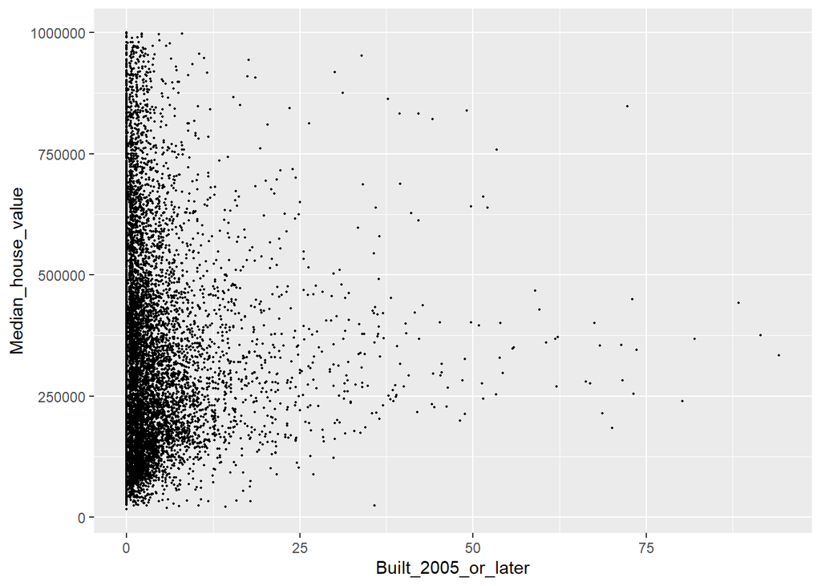

```r
ggplot(data=ca_pa1)+
  geom_point(aes(x=Built_2005_or_later,y=Median_house_value),size=0.3)
```

2. Make a new plot, or pair of plots, which breaks this out by state. Note that the state is recorded in the `STATEFP` variable, with California being state 6 and Pennsylvania state 42.

**解**： 首先根据州的代号(“06”,“42”)新建变量statename存储州的名字(“California”,“Pennsyvania”)。

```r
ca_pa1$statename<-factor(ca_pa1$STATEFP,labels=c("California","Pennsyvania"))
```

之后根据新的变量statename进行分面。

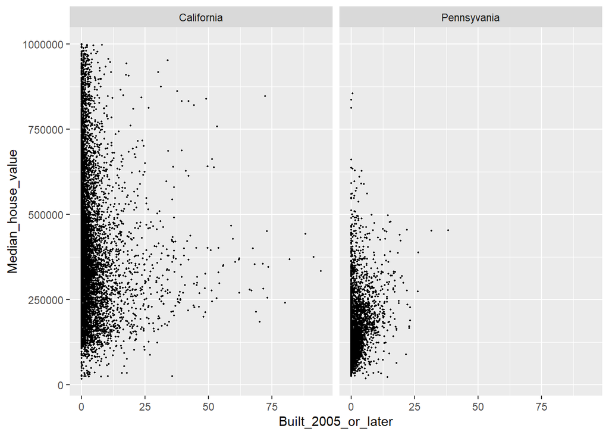

```r
ggplot(data=ca_pa1)+
  geom_point(aes(x=Built_2005_or_later,y=Median_house_value),size=0.3)+
  facet_wrap(~statename)
```

3. *Nobody Home*  
   The vacancy rate is the fraction of housing units which are not occupied. The dataframe contains columns giving the total number of housing units for each Census tract, and the number of vacant housing units.
1. Add a new column to the dataframe which contains the vacancy rate. What are the minimum, maximum, mean, and median vacancy rates?

**解**：

```r
Vacancy_rates<-ca_pa1[["Vacant_units"]]/ca_pa1[["Total_units"]]
ca_pa2<-cbind(ca_pa1,Vacancy_rates)
summary(ca_pa2$Vacancy_rates)
```

```
##    Min. 1st Qu.  Median    Mean 3rd Qu.    Max.
## 0.00000 0.03846 0.06767 0.08889 0.10921 0.96531
```

2. Plot the vacancy rate against median house value.

**解**：

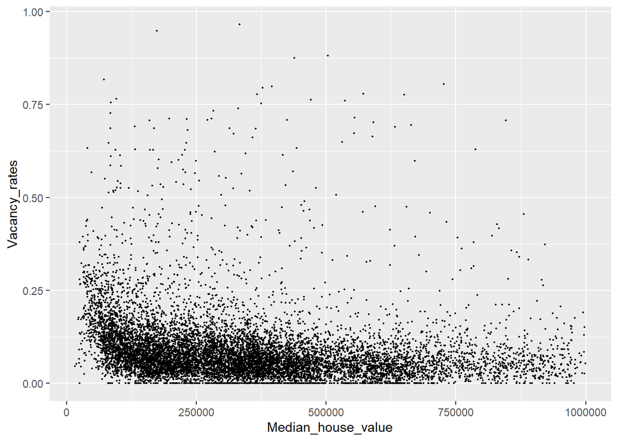

```r
ggplot(data=ca_pa2)+
  geom_point(aes(x=Median_house_value,y=Vacancy_rates),size=0.3)
```

3. Plot vacancy rate against median house value separately for California and for Pennsylvania. Is there a difference?

**解**：

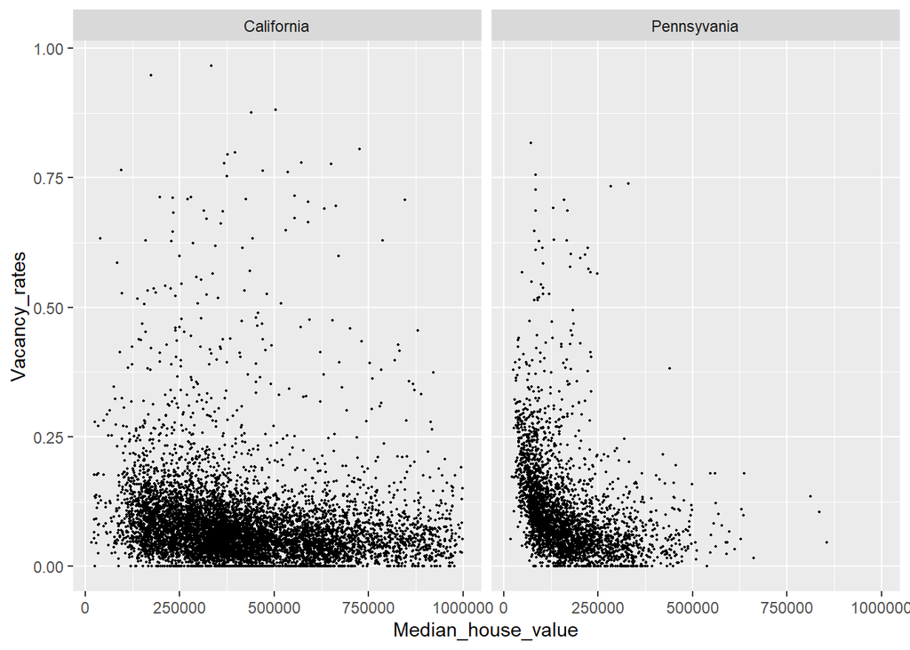

```r
ggplot(data=ca_pa2)+
  geom_point(aes(x=Median_house_value,y=Vacancy_rates),size=0.3)+
  facet_wrap(~statename)
```

Pennsylvania和California比起来整体Median_house_value更低而Vacancy_rates略偏高一点。

4. The column `COUNTYFP` contains a numerical code for counties within each state. We are interested in Alameda County (county 1 in California), Santa Clara (county 85 in California), and Allegheny County (county 3 in Pennsylvania).
1. Explain what the block of code at the end of this question is supposed to accomplish, and how it does it.

```r
acca <- c()
for (tract in 1:nrow(ca_pa2)) {
  if (ca_pa2$STATEFP[tract] == "06") {
    if (ca_pa2$COUNTYFP[tract] == "001") {
      acca <- c(acca, tract)
    }
  }
}
accamhv <- c()
for (tract in acca) {
  accamhv <- c(accamhv, ca_pa2[tract,10])
}
median(accamhv)
```

```
## [1] 474050
```

**解**： 第一个循环将所有满足STATEFP=6(California)，COUNTYFP=1(Alameda County)的行存为一个向量在acca中。 第二个循环将这些行的第十列(Median_house_value)存到一个向量accamhv中。 最后输出accamhv这组数据的median。

2. Give a single line of R which gives the same final answer as the block of code. Note: there are at least two ways to do this; you just have to find one.

**解**：

```r
median(ca_pa2[(ca_pa2[,"STATEFP"]=="06")&(ca_pa2[,"COUNTYFP"]=="001"),10])
```

```
## [1] 474050
```

3. For Alameda, Santa Clara and Allegheny Counties, what were the average percentages of housing built since 2005?

**解**： Alameda：

```r
mean(ca_pa2[(ca_pa2[,"STATEFP"]=="06")&(ca_pa2[,"COUNTYFP"]=="001"),"Built_2005_or_later"])
```

```
## [1] 2.820468
```

Santa Clara:

```r
mean(ca_pa2[(ca_pa2[,"STATEFP"]=="06")&(ca_pa2[,"COUNTYFP"]=="085"),"Built_2005_or_later"])
```

```
## [1] 3.200319
```

Allegheny Counties:

```r
mean(ca_pa2[(ca_pa2[,"STATEFP"]=="42")&(ca_pa2[,"COUNTYFP"]=="003"),"Built_2005_or_later"])
```

```
## [1] 1.474219
```

4. The `cor` function calculates the correlation coefficient between two variables. What is the correlation between median house value and the percent of housing built since 2005 in (i) the whole data, (ii) all of California, (iii) all of Pennsylvania, (iv) Alameda County, (v) Santa Clara County and (vi) Allegheny County?

**解**： $i$

```r
cor(ca_pa2[,"Median_house_value"],ca_pa2[,"Built_2005_or_later"])
```

```
## [1] -0.01893186
```

$ii$

```r
cor(ca_pa2[(ca_pa2[,"STATEFP"]=="06"),"Median_house_value"],ca_pa2[(ca_pa2[,"STATEFP",]=="06"),"Built_2005_or_later"])
```

```
## [1] -0.1153604
```

$iii$

```r
cor(ca_pa2[(ca_pa2[,"STATEFP"]=="42"),"Median_house_value"],ca_pa2[(ca_pa2[,"STATEFP",]=="42"),"Built_2005_or_later"])
```

```
## [1] 0.2681654
```

$iv$

```r
cor(ca_pa2[(ca_pa2[,"STATEFP"]=="06")&(ca_pa2[,"COUNTYFP"]=="001"),"Median_house_value"],ca_pa2[(ca_pa2[,"STATEFP"]=="06")&(ca_pa2[,"COUNTYFP"]=="001"),"Built_2005_or_later"])
```

```
## [1] 0.01303543
```

$v$

```r
cor(ca_pa2[(ca_pa2[,"STATEFP"]=="06")&(ca_pa2[,"COUNTYFP"]=="085"),"Median_house_value"],ca_pa2[(ca_pa2[,"STATEFP"]=="06")&(ca_pa2[,"COUNTYFP"]=="085"),"Built_2005_or_later"])
```

```
## [1] -0.1726203
```

$vi$

```r
cor(ca_pa2[(ca_pa2[,"STATEFP"]=="42")&(ca_pa2[,"COUNTYFP"]=="003"),"Median_house_value"],ca_pa2[(ca_pa2[,"STATEFP"]=="42")&(ca_pa2[,"COUNTYFP"]=="003"),"Built_2005_or_later"])
```

```
## [1] 0.1939652
```

5. Make three plots, showing median house values against median income, for Alameda, Santa Clara, and Allegheny Counties. (If you can fit the information into one plot, clearly distinguishing the three counties, that’s OK too.)

**解**：

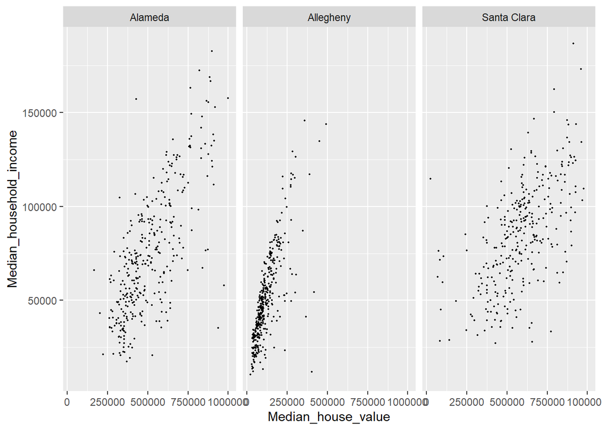

```r
temp=ca_pa2[((ca_pa2[,"STATEFP"]=="42")&(ca_pa2[,"COUNTYFP"]=="003"))|((ca_pa2[,"STATEFP"]=="06")&(ca_pa2[,"COUNTYFP"]=="085"))|((ca_pa2[,"STATEFP"]=="06")&(ca_pa2[,"COUNTYFP"]=="001")),]
v<-c()
for(i in 1:dim(temp)[[1]]){
  if(temp[i,"STATEFP"]=="06"&temp[i,"COUNTYFP"]=="001"){
    v<-c(v,"Alameda")
  }
  if(temp[i,"STATEFP"]=="06"&temp[i,"COUNTYFP"]=="085"){
    v<-c(v,"Santa Clara")
  }
  if(temp[i,"STATEFP"]=="42"&temp[i,"COUNTYFP"]=="003"){
    v<-c(v,"Allegheny")
  }
}
temp<-temp %>% mutate(countyname=v)
ggplot(data=temp)+
  geom_point(aes(x=Median_house_value,y=Median_household_income),size=0.3)+
  facet_wrap("countyname")
```

MB.Ch1.11. Run the following code:

```r
gender <- factor(c(rep("female", 91), rep("male", 92)))
table(gender)
```

```
## gender
## female   male
##     91     92
```

```r
gender <- factor(gender, levels=c("male", "female"))
table(gender)
```

```
## gender
##   male female
##     92     91
```

```r
gender <- factor(gender, levels=c("Male", "female"))
# Note the mistake: "Male" should be "male"
table(gender)
```

```
## gender
##   Male female
##      0     91
```

```r
table(gender, exclude=NULL)
```

```
## gender
##   Male female   <NA>
##      0     91     92
```

```r
rm(gender)  # Remove gender
```

Explain the output from the successive uses of table().

**解**： table函数的作用是统计频次。

第一次的factor将一个向量变为了factor类型，此时的gender的数据是91个female后面跟着92个male，再加一个Levels:female,male。所以此时的table()输出为female:91，male:92。

第二次的factor中用了levels这个属性，levels的作用是选择数据的部分levels为有效值，默认值是将数据的所有levels按升序排列，所以这里是将gender的levels里male放在前面，female放在后面。此时的table()输出就是male:92,female:91

第三次同样用了levels，但Male并不是gender的一个level，所以gender的levels只剩一个female，所有male被丢失为NA。此时table()的输出就是Male:0,female:91。如果计算上缺省值，则table()输出为Male:0,female:91,:92。

MB.Ch1.12. Write a function that calculates the proportion of values in a vector x that exceed some value cutoff.

```r
ecdprop<-function(x,a){
  num1<-length(x)
  num2<-length(which(x>a))
  num2/num1
}
```

1. Use the sequence of numbers 1, 2, . . . , 100 to check that this function gives the result that is expected.

```r
x1<-seq(1:100)
ecdprop(x1,20)
```

```
## [1] 0.8
```

```r
ecdprop(x1,50)
```

```
## [1] 0.5
```

```r
ecdprop(x1,70)
```

```
## [1] 0.3
```

2. Obtain the vector ex01.36 from the Devore6 (or Devore7) package. These data give the times required for individuals to escape from an oil platform during a drill. Use dotplot() to show the distribution of times. Calculate the proportion of escape times that exceed 7 minutes.

```r
library(Devore7)
```

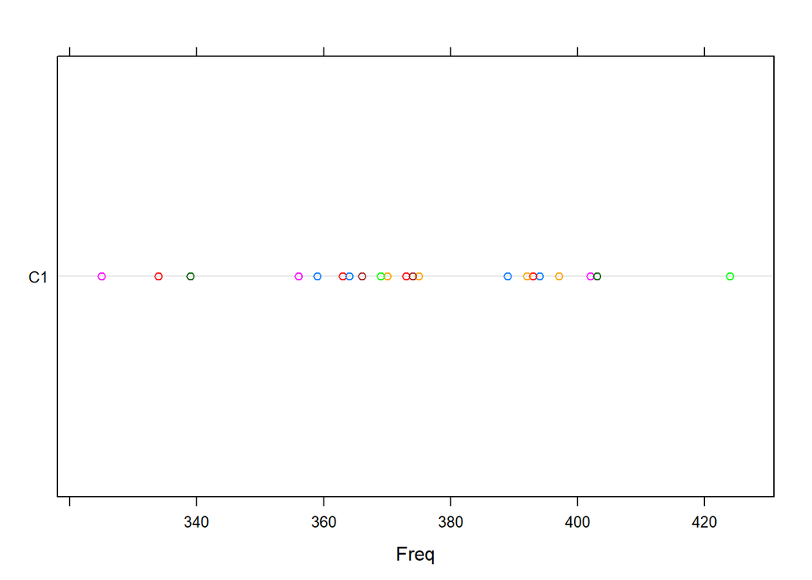

```r
dotplot(t(ex01.36))
```

```r
ecdprop(t(ex01.36),420)
```

```
## [1] 0.03846154
```

MB.Ch1.18. The Rabbit data frame in the MASS library contains blood pressure change measurements on five rabbits (labeled as R1, R2, . . . ,R5) under various control and treatment conditions. Read the help file for more information. Use the unstack() function (three times) to convert Rabbit to the following form:

Treatment Dose R1 R2 R3 R4 R5

1 Control 6.25 0.50 1.00 0.75 1.25 1.5

2 Control 12.50 4.50 1.25 3.00 1.50 1.5

….

```r
Rb1<-unstack(Rabbit,BPchange~Animal)
dose<-unstack(Rabbit,Dose~Animal)
treat<-unstack(Rabbit,Treatment~Animal)
Dose<-dose[,1]
Treatment<-treat[,1]
Rb1<-cbind(Dose,Rb1)
Rb1<-cbind(Treatment,Rb1)
Rb1
```

| Treatment | Dose | R1 | R2 | R3 | R4 | R5 |
| --- | --- | --- | --- | --- | --- | --- |
| Control | 6.25 | 0.50 | 1.00 | 0.75 | 1.25 | 1.5 |
| Control | 12.50 | 4.50 | 1.25 | 3.00 | 1.50 | 1.5 |
| Control | 25.00 | 10.00 | 4.00 | 3.00 | 6.00 | 5.0 |
| Control | 50.00 | 26.00 | 12.00 | 14.00 | 19.00 | 16.0 |
| Control | 100.00 | 37.00 | 27.00 | 22.00 | 33.00 | 20.0 |
| Control | 200.00 | 32.00 | 29.00 | 24.00 | 33.00 | 18.0 |
| MDL | 6.25 | 1.25 | 1.40 | 0.75 | 2.60 | 2.4 |
| MDL | 12.50 | 0.75 | 1.70 | 2.30 | 1.20 | 2.5 |
| MDL | 25.00 | 4.00 | 1.00 | 3.00 | 2.00 | 1.5 |
| MDL | 50.00 | 9.00 | 2.00 | 5.00 | 3.00 | 2.0 |

[output cut: 2 more lines]